# Georreferenciación R

2023-12-14

# Vector data

```r
# Create a longitude-latitude vector
longitude <- c(-116.7, -120.4, -116.7, -113.5, -115.5, -120.8, -119.5, -113.7, -113.7, -110.7)
latitude <- c(45.3, 42.6, 38.9, 42.1, 35.7, 38.9, 36.2, 39, 41.6, 36.9)
lonlat <- cbind(longitude, latitude)

# Create spatvector object, defininga coordinate reference system
crdref <- "+proj=longlat +datum=WGS84"
pts <- vect(lonlat, crs = crdref)
class(pts)
```

```
## [1] "SpatVector"
## attr(,"package")
## [1] "terra"
```

```r
# To check geometry
geom(pts)
```

```
##       geom part      x    y hole
##  [1,]    1    1 -116.7 45.3    0
##  [2,]    2    1 -120.4 42.6    0
##  [3,]    3    1 -116.7 38.9    0
##  [4,]    4    1 -113.5 42.1    0
##  [5,]    5    1 -115.5 35.7    0
##  [6,]    6    1 -120.8 38.9    0
##  [7,]    7    1 -119.5 36.2    0
##  [8,]    8    1 -113.7 39.0    0
##  [9,]    9    1 -113.7 41.6    0
## [10,]   10    1 -110.7 36.9    0
```

```r
# Add variable to Spatvector object
precip <- runif(nrow(lonlat), min = 0, max = 100)
df <- data.frame(ID = 1:nrow(lonlat), precip = precip)
ptv <- vect(lonlat, atts = df, crs = crdref)
geom(ptv)
```

```
##       geom part      x    y hole
##  [1,]    1    1 -116.7 45.3    0
##  [2,]    2    1 -120.4 42.6    0
##  [3,]    3    1 -116.7 38.9    0
##  [4,]    4    1 -113.5 42.1    0
##  [5,]    5    1 -115.5 35.7    0
##  [6,]    6    1 -120.8 38.9    0
##  [7,]    7    1 -119.5 36.2    0
##  [8,]    8    1 -113.7 39.0    0
##  [9,]    9    1 -113.7 41.6    0
## [10,]   10    1 -110.7 36.9    0
```

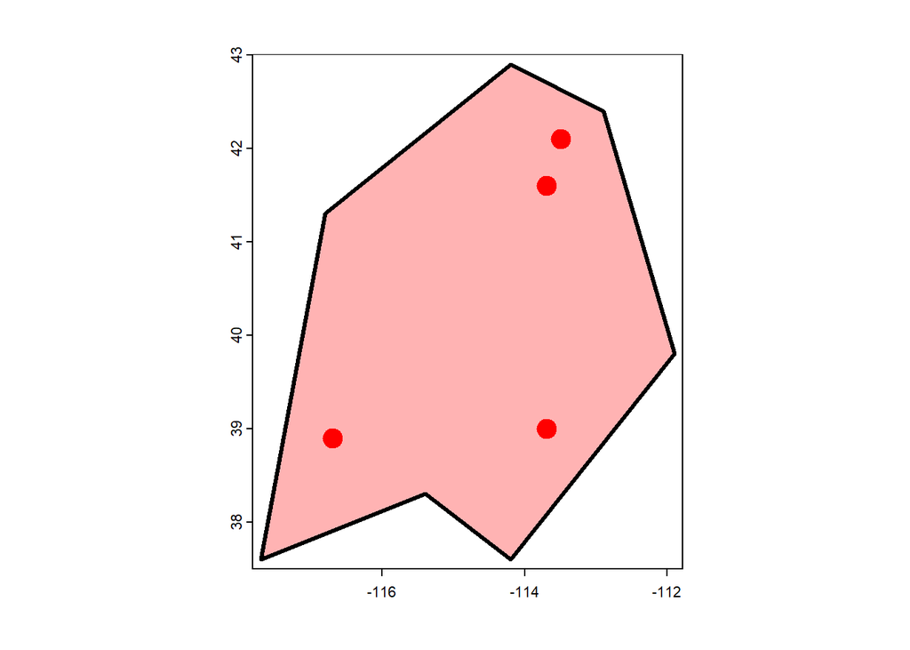

```r
# Creating a SpatVector of lines or polygons
lon <- c(-116.8, -114.2, -112.9, -111.9, -114.2, -115.4, -117.7)
lat <- c(41.3, 42.9, 42.4, 39.8, 37.6, 38.3, 37.6)
lonlat <- cbind(id=1, part=1, lon, lat)

# Líneas
lns <- vect(lonlat, type = "lines", crs = crdref)

# Polígonos
pols <- vect(lonlat, type = "polygons", crs = crdref)

# Plot
plot(pols)
plot(pols, border='black', col= alpha("red", 0.3), lwd=3, add=TRUE)
points(pts, col='red', pch=20, cex=3)
```

# Reading spatial data

The Shapefile is the most commonly used file formate for vector data. The shapefile format is a geospatial vector data format. The shapefile format stores the geometry as primitive geometry shapes (points, lines, and polygons). The shape file format cosists of a colection of files with common filename prefix stored in the same directory:

- .shp = feature geometry
- .shx = shape index format
- .dbf = attribute format
- .prj = projection description
- .sbn = spatial index of the features

The actual shapefile relates specifically to the .shp but alone is incomplete. Here we use a shapefile that comes with the terra package:

## Reading shapefile (terra package)

```r
library(terra)
filename <- system.file("ex/lux.shp", package = "terra")

# Vect function (returns SpatVector of polygons in R) to read the file
s <- vect(filename)
```

## Coordinate Reference Systems (CRS)

The Coordinate Reference System defines a meaningful location of coordinate pairs (by defining origin). The natural coordinate reference system for geographic data is longitude (the longitude of (x,y) is the angle from a reference meridian to meridian that passes through (x,y)) and latitude (the latitude of (x, y) is the angle between equatorial plane and the line that passes through a point and the center of the Earth). The most commonly used datum (for estimating these angles) is WGS84 (World Geodesic System 1984).

The basic way to record a location is a coordinate pair (z, w) in degrees and a reference datum (WGS84, for instance).

A projection procedure is needed to transform this three dimensional angular system to a two dimensional planar system. (Projection = planar coordinate reference systems).

Let’s look at the following example:

```r
# Creating a SpatVect object
p <- vect(system.file("ex/lux.shp", package="terra"))

# Inspect coordinate reference system
crs(p)
```

```
## [1] "GEOGCRS[\"WGS 84\",\n    DATUM[\"World Geodetic System 1984\",\n        ELLIPSOID[\"WGS 84\",6378137,298.257223563,\n            LENGTHUNIT[\"metre\",1]]],\n    PRIMEM[\"Greenwich\",0,\n        ANGLEUNIT[\"degree\",0.0174532925199433]],\n    CS[ellipsoidal,2],\n        AXIS[\"geodetic latitu…
```

```r
# Assigning a different CRS
pp <- p
crs(pp) <- "+proj=longlat +datum=WGS84"
```

# Vector data manipulation

This section aims to manipulate vector data. Let’s look at the following example:

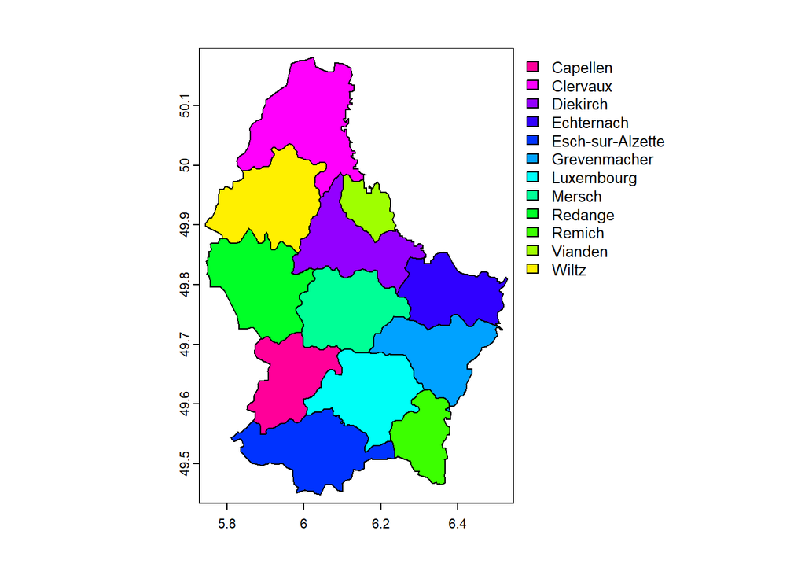

```r
f <- system.file("ex/lux.shp", package = "terra")
p <- vect(f)

# Plot this data
plot(p, "NAME_2")
```

## Geometry and attributes

```r
# To extract attributes (data.frame) from a SpatVector
d <- as.data.frame(p)

# To extract the geometry as a matrix (this is rarely needed)
g <- geom(p)

# To extract geometry as well-known text (polygons)
g <- geom(p, wkt = TRUE)
substr(g, 1, 50)
```

```
##  [1] "POLYGON ((6.026519 50.17767, 6.031361 50.165627, 6"
##  [2] "POLYGON ((6.178368 49.876823, 6.185479 49.870525, "
##  [3] "POLYGON ((5.881378 49.870148, 5.881672 49.868866, "
##  [4] "POLYGON ((6.131309 49.972565, 6.134291 49.972382, "
##  [5] "POLYGON ((5.977929 50.026016, 5.982312 50.022949, "
##  [6] "POLYGON ((6.385532 49.837029, 6.3886 49.833683, 6."
##  [7] "POLYGON ((6.316665 49.623375, 6.31835 49.623157, 6"
##  [8] "POLYGON ((6.425158 49.731644, 6.42657 49.73082, 6."
##  [9] "POLYGON ((5.998312 49.699924, 5.998632 49.698559, "
## [10] "POLYGON ((6.039474 49.448261, 6.036906 49.448696, "
## [11] "POLYGON ((6.155963 49.685047, 6.159284 49.685036, "
## [12] "POLYGON ((6.067982 49.828465, 6.071922 49.825478, "
```

```r
# To extract the variables (STATES)
p$NAME_2
```

```
##  [1] "Clervaux"         "Diekirch"         "Redange"          "Vianden"
##  [5] "Wiltz"            "Echternach"       "Remich"           "Grevenmacher"
##  [9] "Capellen"         "Esch-sur-Alzette" "Luxembourg"       "Mersch"
```

```r
# To create a new variable
p$lets <- sample(letters, nrow(p))

# To get the length of the spatial object
perim(p)
```

```
##  [1] 117100.12  93477.28  84502.45  44919.14  85032.61  74708.05  57991.42
##  [8]  81203.93  74443.82  95564.74  80618.76  70810.67
```

## Merge

```r
# To add atributes to a SpatVector that already has attributes use merge (or cbind)

dfr <- data.frame(District=p$NAME_1, Canton=p$NAME_2, Value=round(runif(length(p), 100, 1000)))
dfr <- dfr[order(dfr$Canton), ]

pm <- merge(p, dfr, by.x=c('NAME_1', 'NAME_2'), by.y=c('District', 'Canton'))
pm
```

```
##  class       : SpatVector
##  geometry    : polygons
##  dimensions  : 12, 8  (geometries, attributes)
##  extent      : 5.74414, 6.528252, 49.44781, 50.18162  (xmin, xmax, ymin, ymax)
##  coord. ref. : lon/lat WGS 84 (EPSG:4326)
##  names       :   NAME_1   NAME_2  ID_1  ID_2  AREA   POP  lets Value
##  type        :    <chr>    <chr> <num> <num> <num> <int> <chr> <num>
##  values      : Diekirch Clervaux     1     1   312 18081     b   868
##                Diekirch Diekirch     1     2   218 32543     r   140
##                Diekirch  Redange     1     3   259 18664     w   301
```

## Append

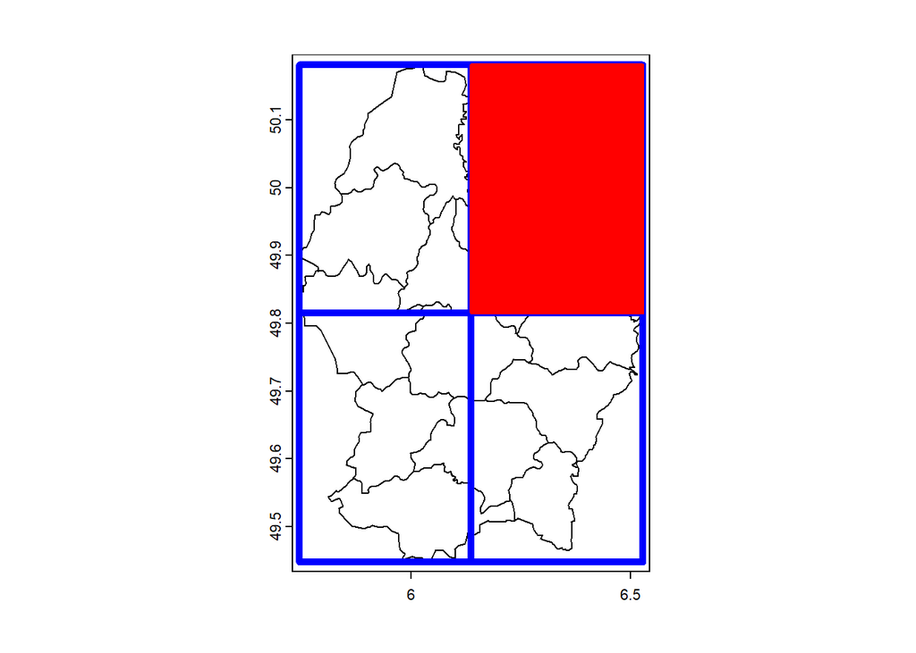

```r
# Defining a multipolygon made up of four polygons
z <- rast(p)
dim(z) <- c(2,2)
values(z) <- 1:4
names(z) <- 'Zone'
# coerce SpatRaster to SpatVector polygons
z <- as.polygons(z)

# This is one of these four polygons
z2 <- z[2,]

plot(p)
plot(z, add=TRUE, border='blue', lwd=5)
plot(z2, add=TRUE, border='red', lwd=2, col='red')
```

## Aggregate

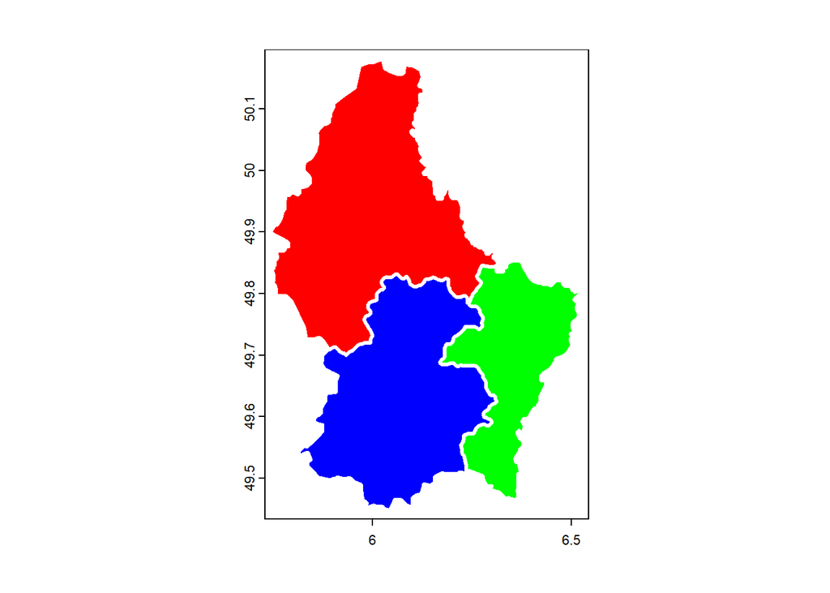

```r
# Aggregate polygons that have the same value for an attribute

pa <- aggregate(p, by = "NAME_1")
plot(pa, col=rainbow(3), lwd=3, border='white')
```

```r
# It is also possible to aggregate polygons without dissolving the borders
pa <- aggregate(p, by = "NAME_1", dissolve = FALSE)
```

## Erase a part of a SpatVector

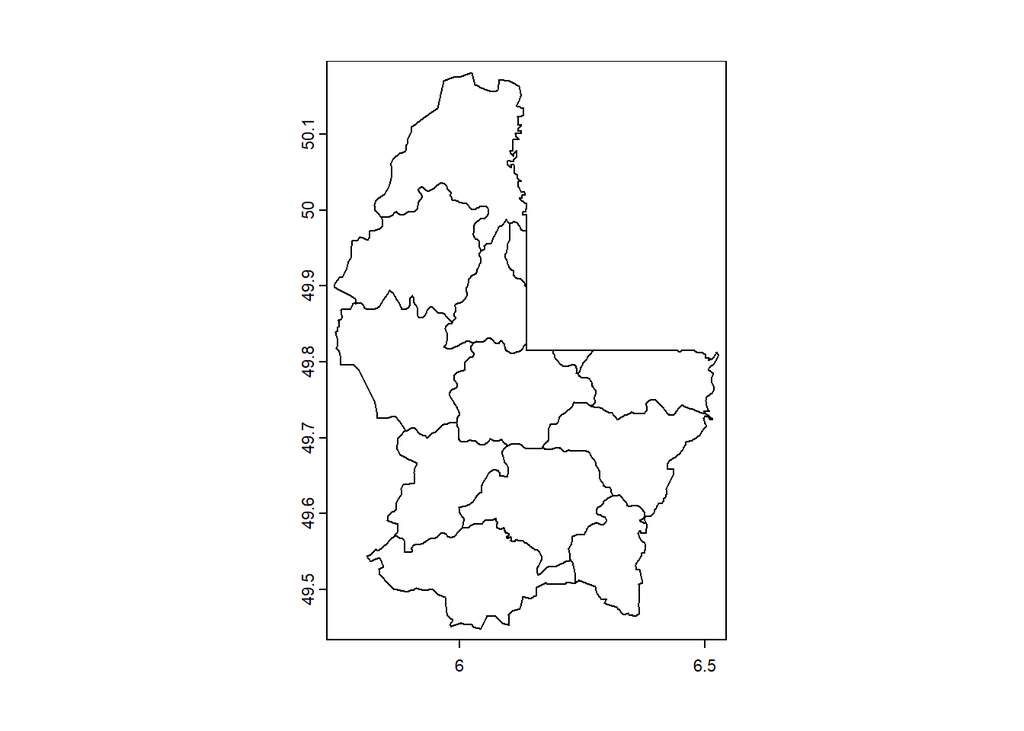

```r
# Eliminar según un polígono
e <- erase(p, z2)
plot(e)
```

## Intersect SpatVector

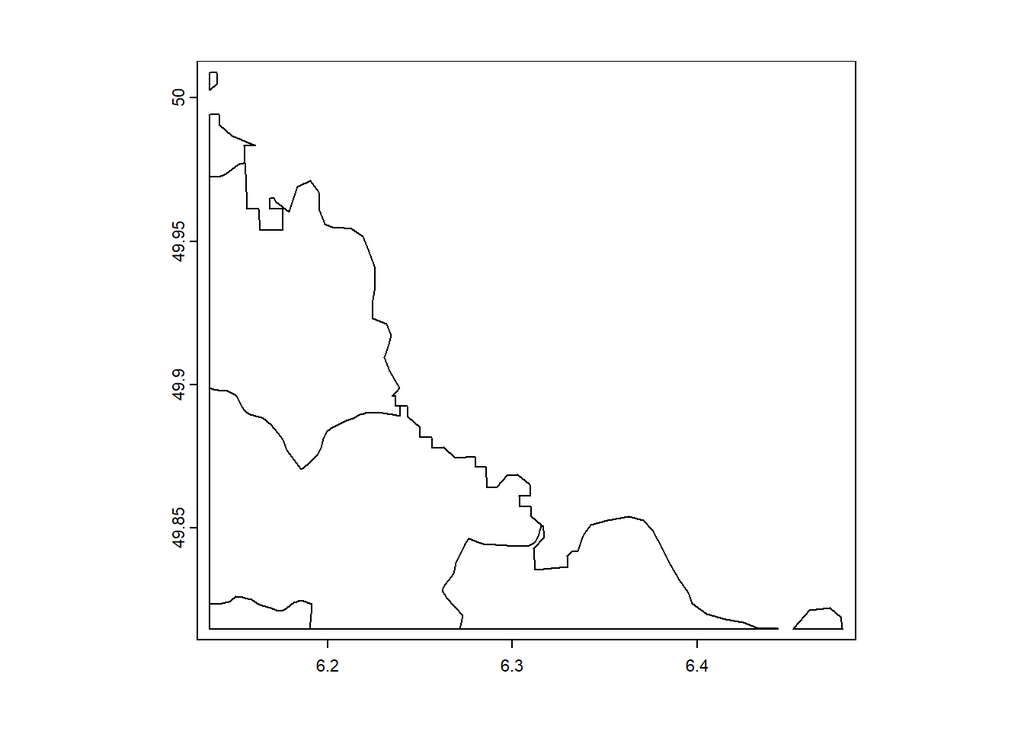

```r
# Eliminar según un polígono
i <- intersect(p, z2)
plot(i)
```

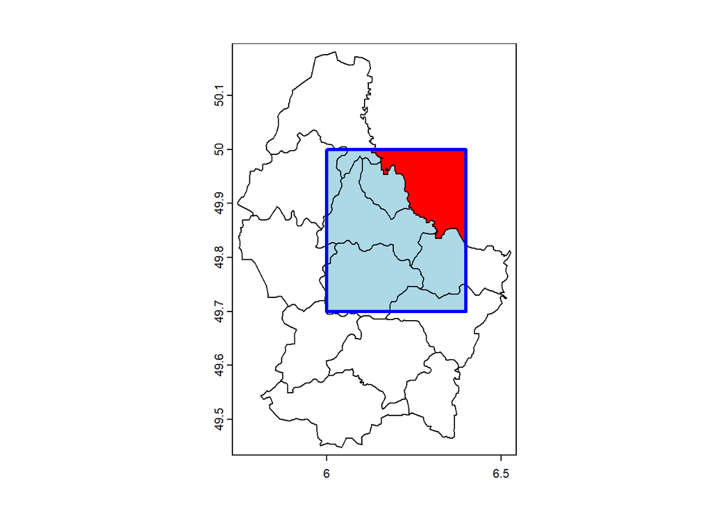

```r
# With crop the geometry of the second argument is not added to the output
e <- ext(6, 6.4, 49.7, 50)
pe <- crop(p, e)
plot(p)
plot(e, add=T, lwd=3, col="red")
plot(pe, add=T, col='light blue')
plot(e, add=T, lwd=3, border="blue")
```

## Union

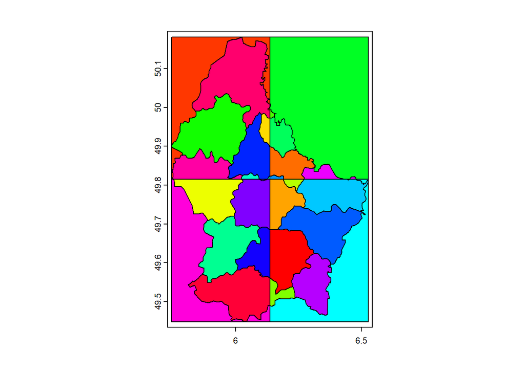

```r
# To get the union of two SpatVectors
u <- union(p, z)

set.seed(5)
plot(u, col=sample(rainbow(length(u))))
```

## Cover

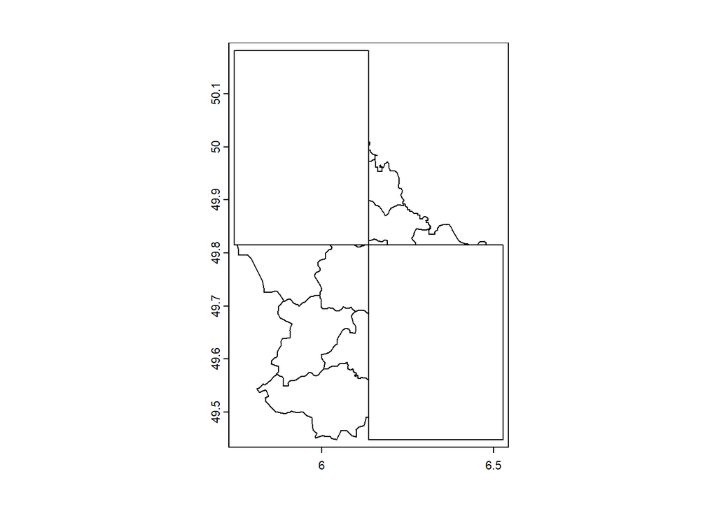

```r
# To get the union of two SpatVectors
cov <- cover(p, z[c(1,4), ])
plot(cov)
```

## Difference

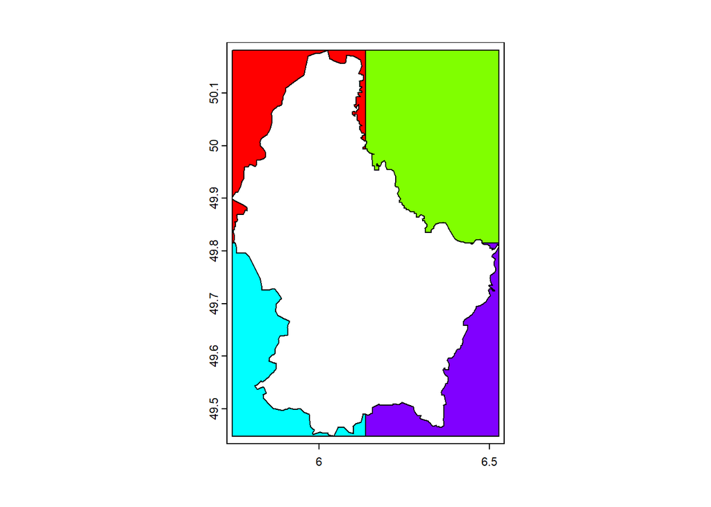

```r
dif <- symdif(z, p)
plot(dif, col=rainbow(length(dif)))
```

## Spatial queries

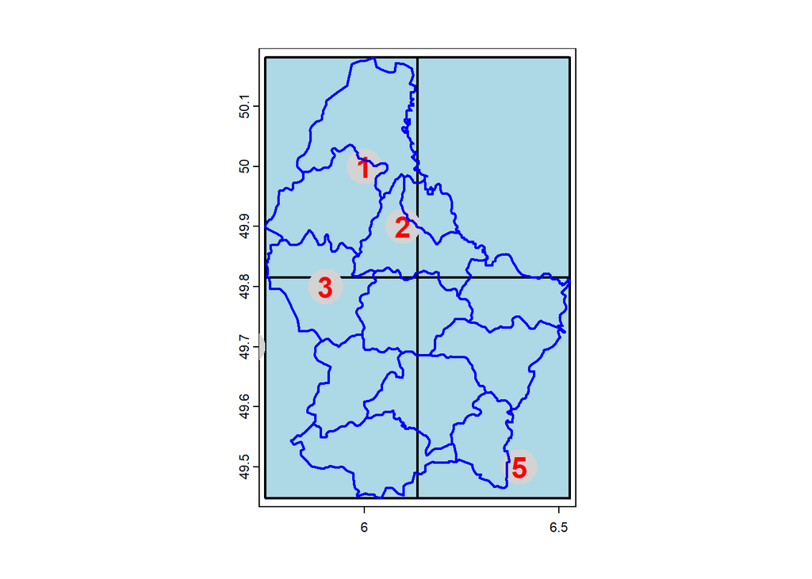

```r
pts <- matrix(c(6, 6.1, 5.9, 5.7, 6.4, 50, 49.9, 49.8, 49.7, 49.5), ncol=2)
spts <- vect(pts, crs=crs(p))
plot(z, col='light blue', lwd=2)
points(spts, col='light gray', pch=20, cex=6)
text(spts, 1:nrow(pts), col='red', font=2, cex=1.5)
lines(p, col='blue', lwd=2)
```

# Maps

You can make a map with plot(x) where x is a SpatVector (or a SpatRaster). Let’s look at the following example data:

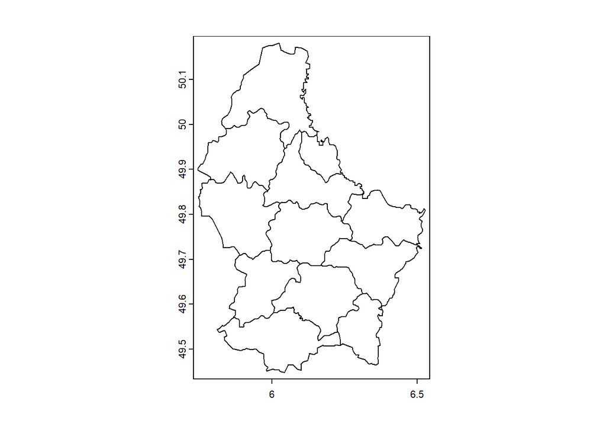

```r
p <- vect(system.file("ex/lux.shp", package="terra"))
plot(p)
```

## Filling by variable

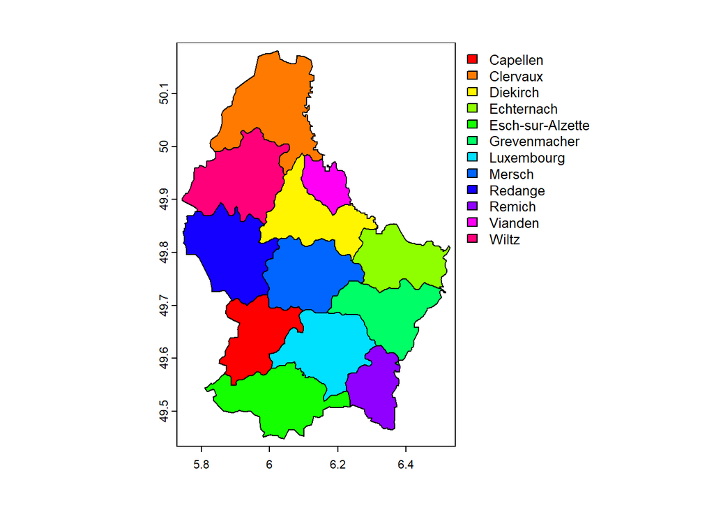

```r
# Diferenciar los niveles de una variable
plot(p, "NAME_2", col=rainbow(25))
```

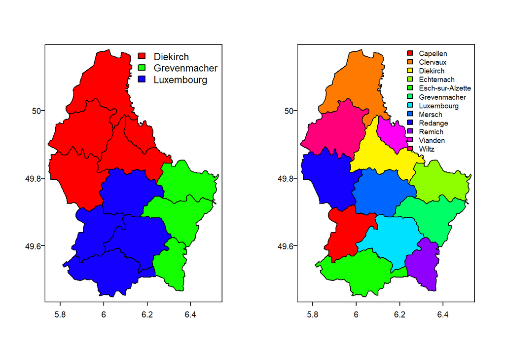

```r
# Mapas para múltiples variables
par(mfrow=c(1,2))
m <- c(3.1, 3.1, 2.1, 2.1)
plot(p, "NAME_1", col=rainbow(25), mar=m, plg=list(x="topright"), pax=list(las=1))
plot(p, "NAME_2", col=rainbow(25), mar=m, plg=list(x="topright", cex=.75), pax=list(las=1))
```

## Combining multiple SpatVectors using lines and points

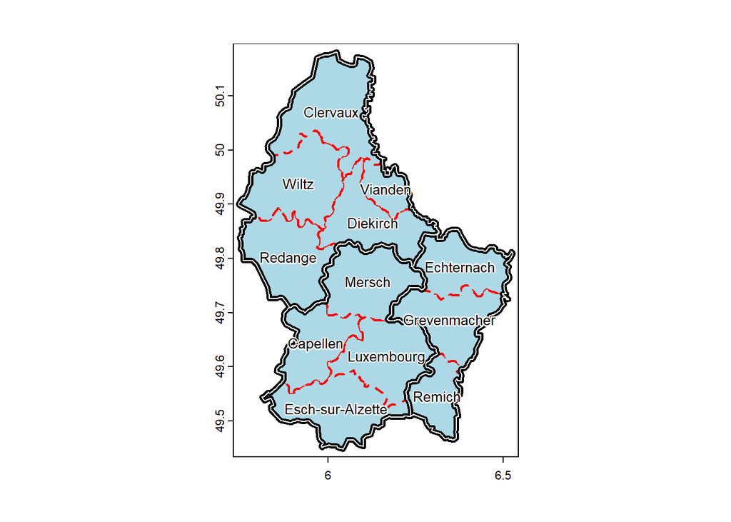

```r
d <- aggregate(p, "NAME_1")
plot(p, col="light blue", lty=2, border="red", lwd=2)
lines(d, lwd=5)
lines(d, col="white", lwd=1)
text(p, "NAME_2", cex=.8, halo=TRUE)
```

# Spatial data analysis

## Zonation (income)

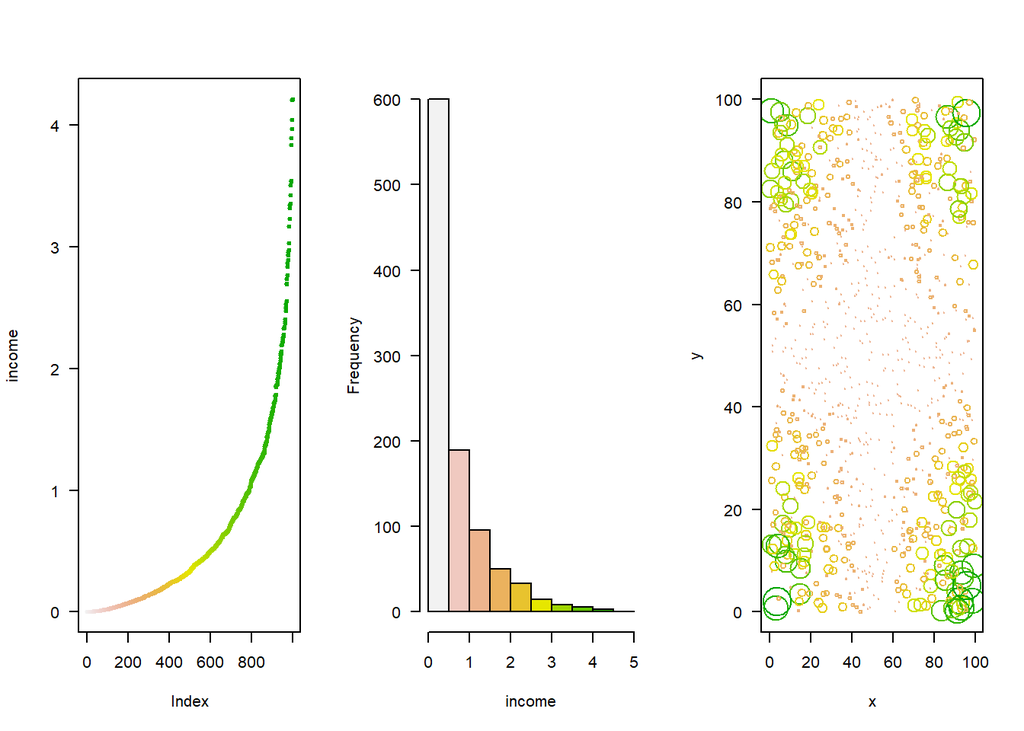

```r
# Ingresos según zona
set.seed(0)

xy <- cbind(x=runif(1000, 0, 100), y=runif(1000, 0, 100))
income <- (runif(1000) * abs((xy[,1] - 50) * (xy[,2] - 50))) / 500

par(mfrow=c(1,3), las=1)
plot(sort(income), col=rev(terrain.colors(1000)), pch=20, cex=.75, ylab='income')
hist(income, main='', col=rev(terrain.colors(10)),  xlim=c(0,5), breaks=seq(0,5,0.5))
plot(xy, xlim=c(0,100), ylim=c(0,100), cex=income, col=rev(terrain.colors(50))[10*(income+1)])
```

```r
# Gini
n <- length(income)
G <- (2 * sum(sort(income) * 1:n)/sum(income) - (n + 1)) / n
G
```

```
## [1] 0.5814548
```

## Distance

### Distance matrix

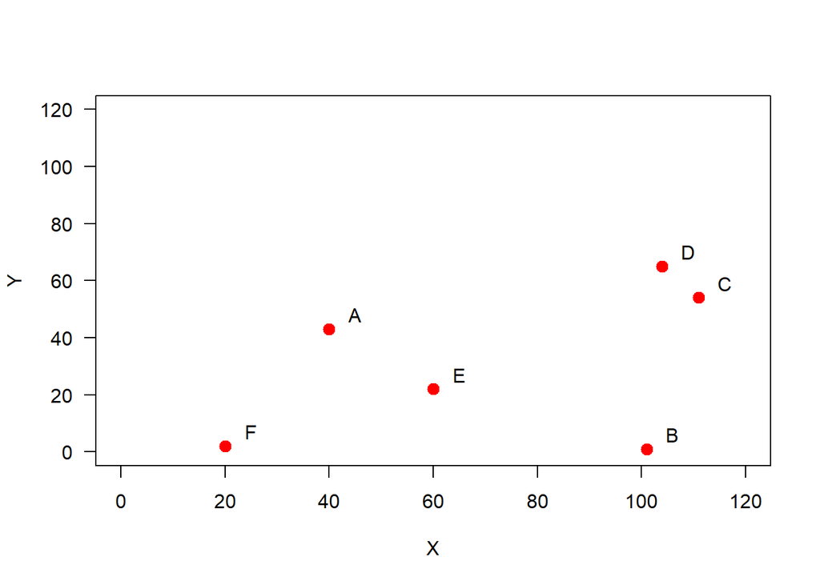

```r
A <- c(40, 43)
B <- c(101, 1)
C <- c(111, 54)
D <- c(104, 65)
E <- c(60, 22)
F <- c(20, 2)
pts <- rbind(A, B, C, D, E, F)

plot(pts, xlim=c(0,120), ylim=c(0,120), pch=20, cex=2, col='red', xlab='X', ylab='Y', las=1)
text(pts+5, LETTERS[1:6])
```

```r
distance_matrix <- dist(pts)
distance_matrix <- distance_matrix %>% as.matrix()
```

## Spatial influence

### Adjacency

```r
a <-  distance_matrix < 50 #Adjacent if they are within distance of 50 from each other
diag(a) <- NA
adj_binary <- a * 1
adj_binary
```

```
##    A  B  C  D  E  F
## A NA  0  0  0  1  1
## B  0 NA  0  0  1  0
## C  0  0 NA  1  0  0
## D  0  0  1 NA  0  0
## E  1  1  0  0 NA  1
## F  1  0  0  0  1 NA
```

### k-nearest neighbours

```r
cols <- apply(distance_matrix, 1, order)
# we need to transpose the result
cols <- t(cols)

# Supóngase k = 2
cols <- cols[, c(2,3)]
cols
```

```
##   [,1] [,2]
## A    5    6
## B    5    3
## C    4    2
## D    3    5
## E    1    6
## F    5    1
```

```r
# Row-column pairs
rowcols <- cbind(rep(1:6, each=2), as.vector(t(cols)))

# Seleccionar k = 2 más cercanos
k_nearest <- adj_binary * 0
k_nearest[rowcols] <- 1
k_nearest
```

```
##    A  B  C  D  E  F
## A NA  0  0  0  1  1
## B  0 NA  1  0  1  0
## C  0  1 NA  1  0  0
## D  0  0  1 NA  1  0
## E  1  0  0  0 NA  1
## F  1  0  0  0  1 NA
```

### Spatial influence for polygons

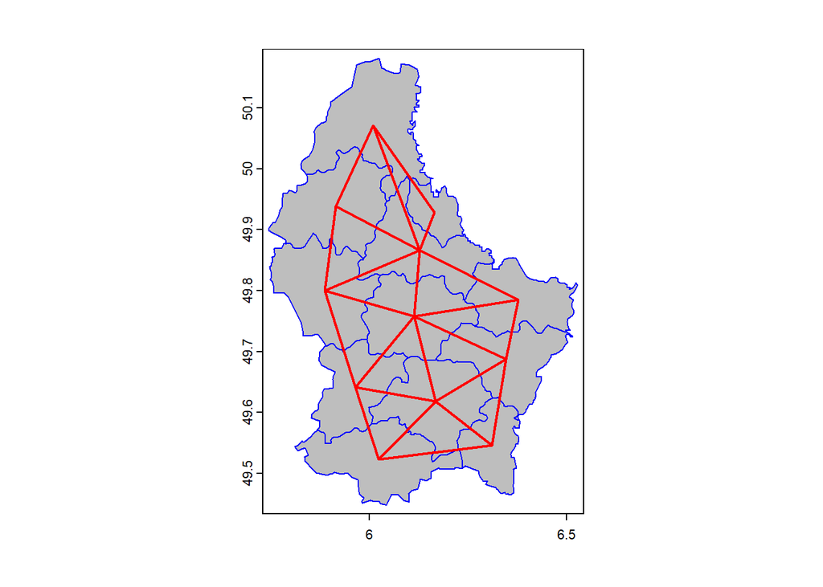

```r
p <- vect(system.file("ex/lux.shp", package="terra"))

# Plot the links between the polygons
plot(p, col="gray", border="blue")
nb <- adjacent(p, "rook")
v <- centroids(p)
p1 <- v[nb[,1], ]
p2 <- v[nb[,2], ]
lines(p1, p2, col="red", lwd=2)
```

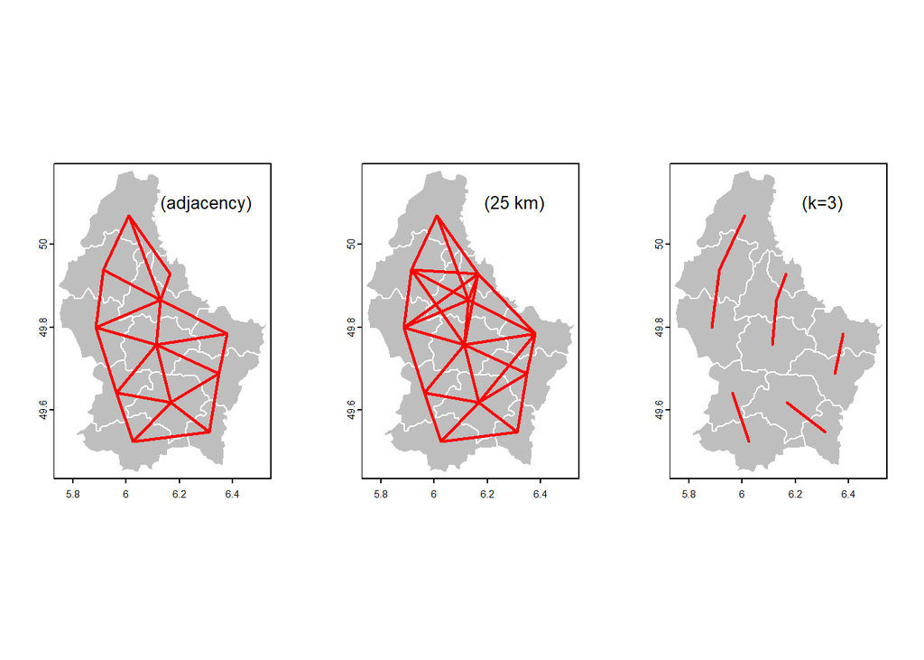

```r
# Distance based
wd25 <- nearby(v, distance=25000)

# Nearest neighbors
k3 <- nearby(v, k=3)


plotit <- function(nb, lab='') {
  plot(p, col='gray', border='white')
  v <- centroids(p)
  p1 <- v[nb[,1], ,drop=FALSE]
  p2 <- v[nb[,2], ,drop=FALSE]
  lines(p1, p2, col="red", lwd=2)
  text(6.3, 50.1, paste0('(', lab, ')'), cex=1.25)
}

par(mfrow=c(1, 3), mai=c(0,0,0,0))
plotit(nb, "adjacency")
plotit(wd25, "25 km")
plotit(k3, "k=3")
```

```r
#
```

## Spatial autocorrelation

### Example data

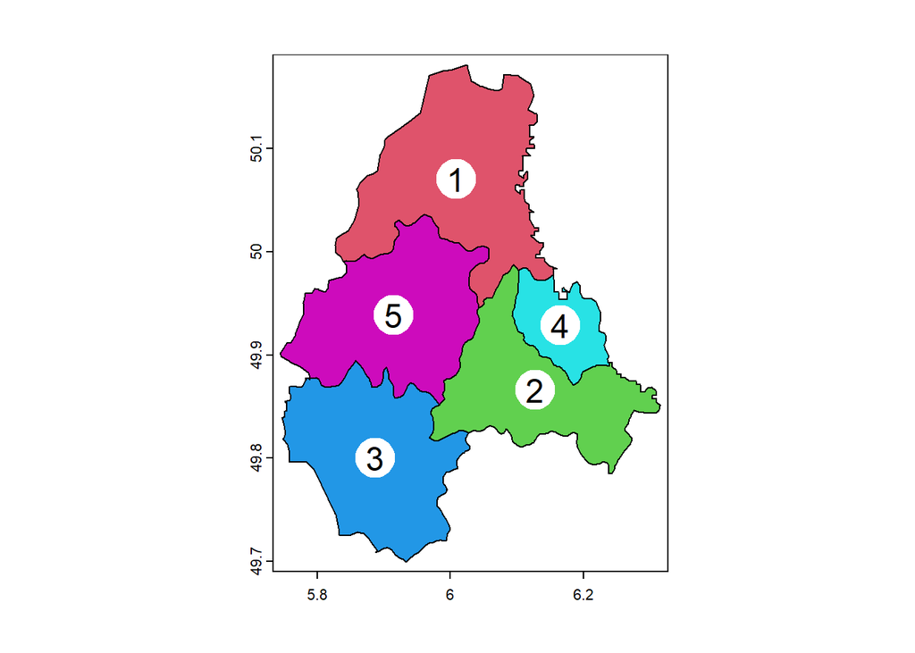

```r
p <- vect(system.file("ex/lux.shp", package="terra"))
p <- p[p$NAME_1=="Diekirch", ]
p$value <- c(10, 6, 4, 11, 6)

par(mai=c(0,0,0,0))
plot(p, col=2:7)
xy <- centroids(p)
points(xy, cex=6, pch=20, col='white')
text(p, 'ID_2', cex=1.5)
```

### Adjacent polygons

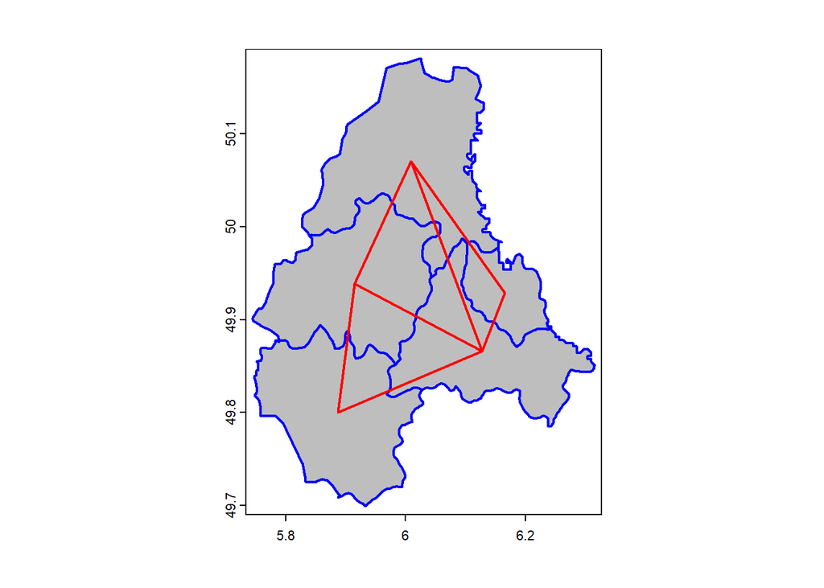

```r
w <- adjacent(p, symmetrical=TRUE)

# Plot the links between the polygons
plot(p, col='gray', border='blue', lwd=2)
p1 <- xy[w[,1], ]
p2 <- xy[w[,2], ]
lines(p1, p2, col='red', lwd=2)
```

### Compute Moran’s I

```r
ww <-  adjacent(p, "queen", pairs=FALSE)
ac <- terra::autocor(p$value, w = ww, method = "moran")
```

### Test for significance using Monte Carlos Simulation

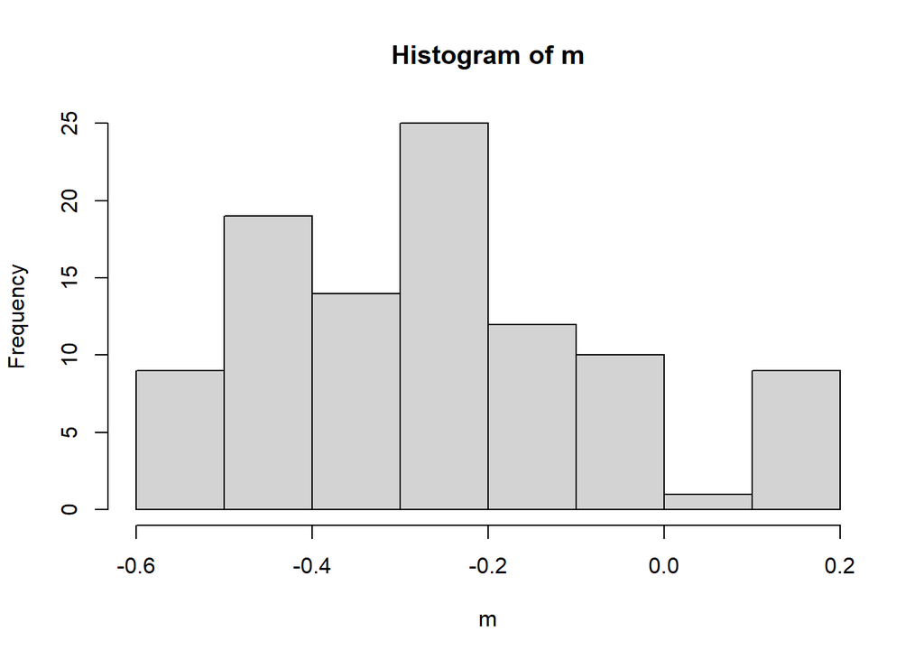

```r
m <- sapply(1:99, function(i) {
    autocor(sample(p$value), ww, "moran")
})
hist(m)
```

```r
pval <- sum(m >= ac) / 100
pval
```

```
## [1] 0.01
```

### Moran scatter plot

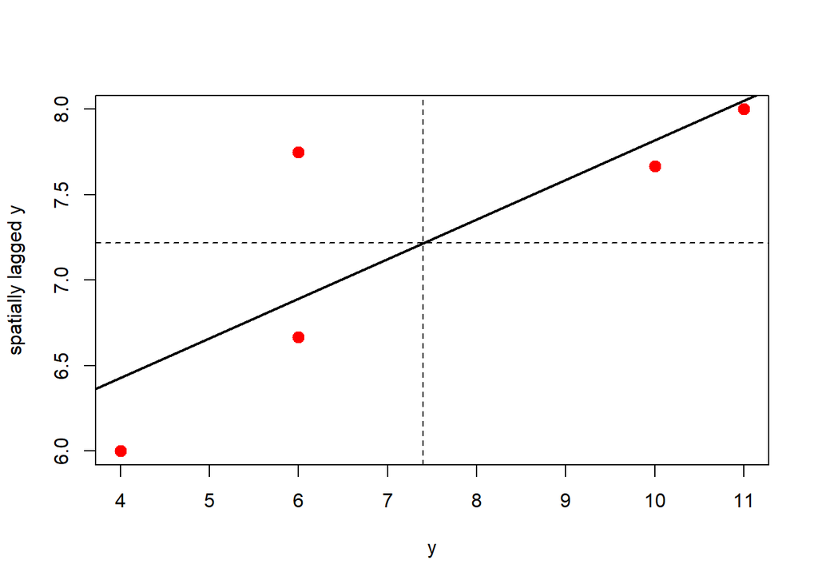

```r
n <- length(p)
y <- p$value
ybar <- mean(y)
wm <- adjacent(p, pairs=FALSE) # Spatial weights matrix
ms <- cbind(id=rep(1:n, each=n), y=rep(y, each=n), value=as.vector(wm * y))

ms <- ms[ms[,3] > 0, ]

ams <- aggregate(ms[,2:3], list(ms[,1]), FUN=mean)
ams <- ams[,-1]
colnames(ams) <- c('y', 'spatially lagged y')

plot(ams, pch=20, col="red", cex=2)
reg <- lm(ams[,2] ~ ams[,1])
abline(reg, lwd=2)
abline(h=mean(ams[,2]), lt=2)
abline(v=ybar, lt=2)
```

```r
# the slope of the regression line has a similar magnitude as Moran's I
coefficients(reg)[2]
```

```
##  ams[, 1]
## 0.2315341
```